# Analysis

```r
tdata <- read_csv("exp_data.csv")
```

```r
# Exclude subjects who failed the control questions
tdata <- subset(tdata, intro_check == "2: A little squid swam from the right to the left.")
tdata <- subset(tdata, timing_check_correct == "correct")
tdata <- subset(tdata, learning_check_correct == "correct")
```

# 1 Subject demographics

```r
# demographics

min(tdata$age)
```

```
## [1] 19
```

```r
max(tdata$age)
```

```
## [1] 70
```

```r
mean(tdata$age)
```

```
## [1] 39.25
```

```r
sd(tdata$age)
```

```
## [1] 12.71393
```

```r
# 1 = male, 2 = female, 3 = other
table(tdata$gender)
```

```
##
##   1: male 2: female
##        55        45
```

# 2 Data preparations

Check n in each condition:

```r
table(tdata$structure, tdata$first_object)
```

```
##
##                left right
##   irreversible   25    25
##   reversible     25    25
```

Factorize:

```r
tdata$structure <- factor(tdata$structure, levels = c("irreversible", "reversible"), labels = c("irreversible", "reversible"))
```

Relabel rating columns for red and yellow entity according to “first object” (so that they are called first_obj_rating and second_obj_rating):

```r
left_first <- subset(tdata, first_object == "left")
colnames(left_first)[10] ="first_obj_caused_rating"
colnames(left_first)[11] ="second_obj_caused_rating"
colnames(left_first)[12] ="first_obj_maintained_rating"
colnames(left_first)[13] ="second_obj_maintained_rating"

right_first <- subset(tdata, first_object == "right")
colnames(right_first)[11] ="first_obj_caused_rating"
colnames(right_first)[10] ="second_obj_caused_rating"
colnames(right_first)[13] ="first_obj_maintained_rating"
colnames(right_first)[12] ="second_obj_maintained_rating"

right_first <- right_first[c("subj_code", "condition", "desktop_conf", "attent_conf", "intro_check",
                             "structure", "first_object", "learn_check_left", "learn_check_right",
                             "first_obj_caused_rating", "second_obj_caused_rating", "first_obj_maintained_rating", "second_obj_maintained_rating",
                             "timing_check", "recorded_at",
                             "age", "gender", "tech_issues", "timing_check_correct", "learning_check_left_correct",
                             "learning_check_right_correct", "learning_check_correct")]


names(left_first) %in% names(right_first)
```

```
##  [1] TRUE TRUE TRUE TRUE TRUE TRUE TRUE TRUE TRUE TRUE TRUE TRUE TRUE TRUE TRUE
## [16] TRUE TRUE TRUE TRUE TRUE TRUE TRUE
```

```r
tdata <- rbind(left_first, right_first)
```

Make a subset containing only the columns relevant for analyses and turn into long format:

```r
# Subset:
tdata_sub <- subset(tdata, select = c("subj_code","structure","first_obj_caused_rating", "second_obj_caused_rating",
                                      "first_obj_maintained_rating", "second_obj_maintained_rating"))

# into long format:
library(tidyr)
tdata_long <- gather(tdata_sub, entity, rating, 3:6)


# factorize entity
tdata_long$entity <- factor(tdata_long$entity, levels = c("first_obj_caused_rating", "second_obj_caused_rating",
                                                          "first_obj_maintained_rating", "second_obj_maintained_rating"),
                            labels = c("first \ncaused", "second \ncaused","first \nmaintained", "second \nmaintained"))
```

# 3 Graphs and summaries

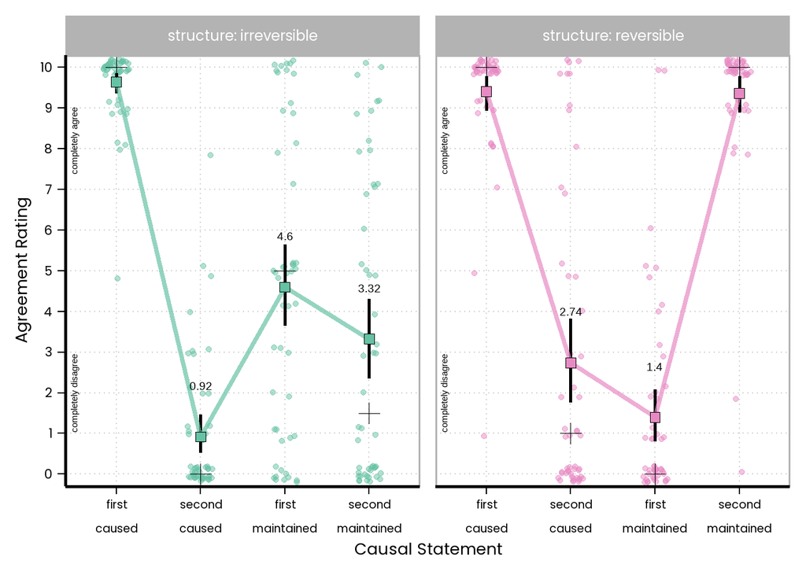

```r
myTheme <- theme(plot.title = element_text(face="bold", size = 22),
        axis.title.x = element_text(size = 20),
        axis.title.y = element_text(size = 20),
        axis.text.x = element_text(size = 14, angle = 0),
        axis.text.y = element_text(size = 16, angle = 0),
        legend.text = element_text(size = 18),
        legend.title = element_text(face = "bold", size = 18),
        strip.text.x = element_text(size = 18),
        panel.grid.major = element_blank(),
        panel.grid.minor = element_blank(),
        panel.background = element_blank(),
        axis.line.x = element_line(colour = "black"),
        axis.line.y = element_line(colour = "black"),
        axis.text = element_text(colour ="black"),
        axis.ticks = element_line(colour ="black"))


tdata_sub <- tdata_long


library(see)
## first, turn sID into a factor
tdata_sub$subj_code <- factor(tdata_sub$subj_code)

pd <- position_dodge(width = 0.3)

tdata_sub$valueJitter <- jitter(tdata_sub$rating, factor = 0.01, amount = 0.004)

theme_set(theme_light(base_size = 20, base_family = "Poppins"))


g <- ggplot(tdata_sub, aes(x = entity, y = valueJitter)) +
  guides(fill=FALSE)+
  facet_grid( ~ structure,labeller = label_both)+
  scale_y_continuous(limits = c(-0.3, 10.3), breaks=seq(0, 10, 1), expand = c(0,0)) +
  geom_jitter(aes(color = structure), alpha = 0.5, width = 0.15, height = 0.2) +
  stat_summary(aes(y = rating, group=1), fun.data = mean_cl_boot,
               geom = "errorbar", width = 0, size = 1) +
  stat_summary(aes(y = rating, group=1, color = structure), fun.y=mean, geom="line",
               shape = 22, size = 1.5, alpha = .7)+
  stat_summary(aes(y = rating, group=1, fill = structure), fun.y=mean, geom="point",
               color = "black", shape = 22, size = 3, group=1, alpha = 1)+
  stat_summary(aes(y = rating,group=1), fun.y=median, geom="point", color = "black", shape = 3, size = 4,
               group=1, alpha = 1, position = position_dodge(width = 0.5))+
  labs(x = "Causal Statement", y = "Agreement Rating") +
  scale_color_manual(name = "Strength",values=c("#66c2a5", "#e78ac3", "#8da0cb", "#a6d854"))+
  scale_fill_manual(name = "Strength",values=c("#66c2a5", "#e78ac3", "#8da0cb", "#a6d854"))+
  theme(legend.position = "none")+
  myTheme+
  theme(panel.grid.major = element_line(color = "lightgrey",
                                        size = 0.5,
                                        linetype = 'dotted'))+
  stat_summary(aes(label=round(after_stat(y),2)), fun.y=mean, geom="text", size=5,
             vjust = -6)+
  annotate("text", x = 0.5, y = 2, label = c("completely disagree"), angle = 90)+
  annotate("text", x = 0.5, y = 8.2, label = c("completely agree"), angle = 90)

g
```

```r
#ggsave("results_means_mainDV.svg",width=12,height=5)
#ggsave("results_means_mainDV.pdf",width=12,height=5)
```

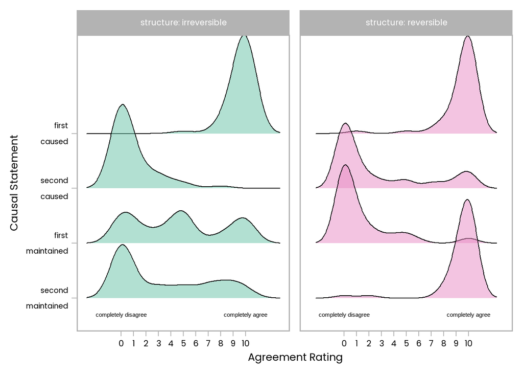

```r
library(ggridges)
g2 <- ggplot(tdata_long, aes(x = rating, y = entity, fill = structure)) +
  facet_grid( ~ structure,labeller = label_both)+
  scale_x_continuous(breaks = seq(0, 10, 1))+
  geom_density_ridges(alpha = 0.5)+
   #stat_summary(aes(x = rating_rec), fun.x=mean, geom="point",
  #             color = "black", shape = 22, size = 2, group=1, alpha = 1)+
  scale_fill_manual(values=c("#66c2a5", "#e78ac3", "#8da0cb", "#a6d854"))+
  #scale_fill_viridis_c(name = "Explanation \nRating", option = "C", breaks=c(-5,0,5), labels=c("narrow scope", "no preference", "broad scope"))+
  labs(x = "Agreement Rating", y = "Causal Statement") +
  scale_y_discrete(limits=rev)+
  myTheme+
  theme_light(base_family = "Poppins", base_size = 20)+
  theme(panel.grid = element_blank(), axis.text = element_text(colour ="black"))+
  theme(legend.position="none",
        legend.title=element_blank(),legend.key.width = unit(1.95, 'cm'))+
  theme(axis.text.y = element_text(size = 14, angle = 0))+
  annotate("text", y = 0.7, x = 0, label = c("completely disagree"), angle = 0)+
  annotate("text", y = 0.7, x = 10, label = c("completely agree"), angle = 0)

g2
```

```r
#ggsave("results_dist.svg",width=12,height=5)
#ggsave("results_dist.pdf",width=12,height=5)
```

# 4 Analyses

## 4.1 Mixed ANOVA

```r
library(afex)
library(emmeans)

a1 <- aov_car(rating ~ structure*entity + Error(subj_code/entity), tdata_long, anova_table = list(es = "pes"))
a1
```

```
## Anova Table (Type 3 tests)
##
## Response: rating
##             Effect           df  MSE          F  pes p.value
## 1        structure        1, 98 6.42  19.03 *** .163   <.001
## 2           entity 2.67, 261.83 8.02 168.69 *** .633   <.001
## 3 structure:entity 2.67, 261.83 8.02  52.73 *** .350   <.001
## ---
## Signif. codes:  0 '***' 0.001 '**' 0.01 '*' 0.05 '+' 0.1 ' ' 1
##
## Sphericity correction method: GG
```

Predicted interaction effect was significant-

Visualize also the obtained main effect of “structure” (reversibility)

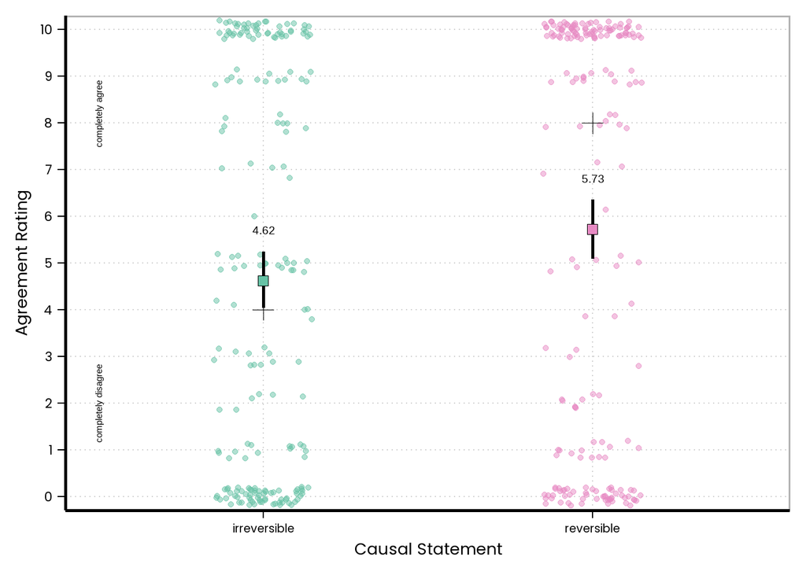

```r
tdata_sub <- tdata_long


library(see)
## first, turn sID into a factor
tdata_sub$subj_code <- factor(tdata_sub$subj_code)

pd <- position_dodge(width = 0.3)

tdata_sub$valueJitter <- jitter(tdata_sub$rating, factor = 0.01, amount = 0.004)

theme_set(theme_light(base_size = 20, base_family = "Poppins"))


g <- ggplot(tdata_sub, aes(x = structure, y = valueJitter)) +
  guides(fill=FALSE)+

  scale_y_continuous(limits = c(-0.3, 10.3), breaks=seq(0, 10, 1), expand = c(0,0)) +
  geom_jitter(aes(color = structure), alpha = 0.5, width = 0.15, height = 0.2) +
  stat_summary(aes(y = rating, group=1), fun.data = mean_cl_boot,
               geom = "errorbar", width = 0, size = 1) +
  stat_summary(aes(y = rating, group=1, fill = structure), fun.y=mean, geom="point",
               color = "black", shape = 22, size = 3, group=1, alpha = 1)+
  stat_summary(aes(y = rating,group=1), fun.y=median, geom="point", color = "black", shape = 3, size = 4,
               group=1, alpha = 1, position = position_dodge(width = 0.5))+
  labs(x = "Causal Statement", y = "Agreement Rating") +
  scale_color_manual(name = "Strength",values=c("#66c2a5", "#e78ac3", "#8da0cb", "#a6d854"))+
  scale_fill_manual(name = "Strength",values=c("#66c2a5", "#e78ac3", "#8da0cb", "#a6d854"))+
  theme(legend.position = "none")+
  myTheme+
  theme(panel.grid.major = element_line(color = "lightgrey",
                                        size = 0.5,
                                        linetype = 'dotted'))+
  stat_summary(aes(label=round(after_stat(y),2)), fun.y=mean, geom="text", size=5,
             vjust = -6)+
  annotate("text", x = 0.5, y = 2, label = c("completely disagree"), angle = 90)+
  annotate("text", x = 0.5, y = 8.2, label = c("completely agree"), angle = 90)

g
```

Plot main effect of entity (causal statement):

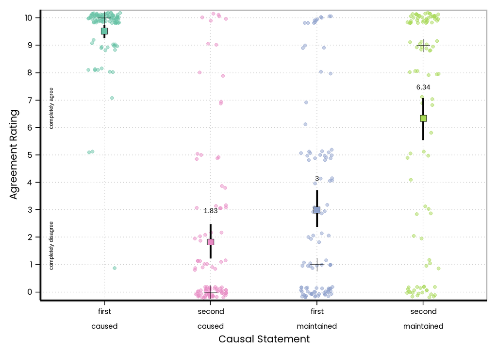

```r
tdata_sub <- tdata_long


library(see)
## first, turn sID into a factor
tdata_sub$subj_code <- factor(tdata_sub$subj_code)

pd <- position_dodge(width = 0.3)

tdata_sub$valueJitter <- jitter(tdata_sub$rating, factor = 0.01, amount = 0.004)

theme_set(theme_light(base_size = 20, base_family = "Poppins"))

g <- ggplot(tdata_sub, aes(x = entity, y = valueJitter)) +
  guides(fill=FALSE)+
  scale_y_continuous(limits = c(-0.3, 10.3), breaks=seq(0, 10, 1), expand = c(0,0)) +
  geom_jitter(aes(color = entity), alpha = 0.5, width = 0.15, height = 0.2) +
  stat_summary(aes(y = rating, group=1), fun.data = mean_cl_boot,
               geom = "errorbar", width = 0, size = 1) +
  stat_summary(aes(y = rating, group=1, fill = entity), fun.y=mean, geom="point",
               color = "black", shape = 22, size = 3, group=1, alpha = 1)+
  stat_summary(aes(y = rating,group=1), fun.y=median, geom="point", color = "black", shape = 3, size = 4,
               group=1, alpha = 1, position = position_dodge(width = 0.5))+
  labs(x = "Causal Statement", y = "Agreement Rating") +
  scale_color_manual(name = "Strength",values=c("#66c2a5", "#e78ac3", "#8da0cb", "#a6d854"))+
  scale_fill_manual(name = "Strength",values=c("#66c2a5", "#e78ac3", "#8da0cb", "#a6d854"))+
  theme(legend.position = "none")+
  annotate("text", x = 0.5, y = 1.7, label = c("completely disagree"), angle = 90)+
  annotate("text", x = 0.5, y = 6.7, label = c("completely agree"), angle = 90)+
  myTheme+
  theme(panel.grid.major = element_line(color = "lightgrey",
                                        size = 0.5,
                                        linetype = 'dotted'))+
  stat_summary(aes(label=round(after_stat(y),2)), fun.y=mean, geom="text", size=5,
             vjust = -6)

g
```

## 4.2 Contrasts

```r
library(lsmeans)
# means

ls2 <- lsmeans(a1, c("structure", "entity"))
ls2
```

```
##  structure    entity             lsmean    SE df lower.CL upper.CL
##  irreversible first..caused        9.64 0.178 98    9.286     9.99
##  reversible   first..caused        9.40 0.178 98    9.046     9.75
##  irreversible second..caused       0.92 0.408 98    0.110     1.73
##  reversible   second..caused       2.74 0.408 98    1.930     3.55
##  irreversible first..maintained    4.60 0.437 98    3.733     5.47
##  reversible   first..maintained    1.40 0.437 98    0.533     2.27
##  irreversible second..maintained   3.32 0.409 98    2.508     4.13
##  reversible   second..maintained   9.36 0.409 98    8.548    10.17
##
## Confidence level used: 0.95
```

```r
contrasts <- emmeans(a1, ~ entity|structure)
s <- pairs(contrasts, adjust = "none")


s
```

```
## structure = irreversible:
##  contrast                               estimate    SE df t.ratio p.value
##  first..caused - second..caused             8.72 0.492 98  17.715  <.0001
##  first..caused - first..maintained          5.04 0.473 98  10.657  <.0001
##  first..caused - second..maintained         6.32 0.443 98  14.272  <.0001
##  second..caused - first..maintained        -3.68 0.587 98  -6.266  <.0001
##  second..caused - second..maintained       -2.40 0.571 98  -4.200  0.0001
##  first..maintained - second..maintained     1.28 0.617 98   2.073  0.0408
##
## structure = reversible:
##  contrast                               estimate    SE df t.ratio p.value
##  first..caused - second..caused             6.66 0.492 98  13.530  <.0001
##  first..caused - first..maintained          8.00 0.473 98  16.916  <.0001
##  first..caused - second..maintained         0.04 0.443 98   0.090  0.9282
##  second..caused - first..maintained         1.34 0.587 98   2.282  0.0247
##  second..caused - second..maintained       -6.62 0.571 98 -11.586  <.0001
##  first..maintained - second..maintained    -7.96 0.617 98 -12.892  <.0001
```

```r
confint(s, level = 0.95)
```

```
## structure = irreversible:
##  contrast                               estimate    SE df lower.CL upper.CL
##  first..caused - second..caused             8.72 0.492 98   7.7432    9.697
##  first..caused - first..maintained          5.04 0.473 98   4.1015    5.979
##  first..caused - second..maintained         6.32 0.443 98   5.4413    7.199
##  second..caused - first..maintained        -3.68 0.587 98  -4.8455   -2.515
##  second..caused - second..maintained       -2.40 0.571 98  -3.5339   -1.266
##  first..maintained - second..maintained     1.28 0.617 98   0.0547    2.505
##
## structure = reversible:
##  contrast                               estimate    SE df lower.CL upper.CL
##  first..caused - second..caused             6.66 0.492 98   5.6832    7.637
##  first..caused - first..maintained          8.00 0.473 98   7.0615    8.939
##  first..caused - second..maintained         0.04 0.443 98  -0.8387    0.919
##  second..caused - first..maintained         1.34 0.587 98   0.1745    2.505
##  second..caused - second..maintained       -6.62 0.571 98  -7.7539   -5.486
##  first..maintained - second..maintained    -7.96 0.617 98  -9.1853   -6.735
##
## Confidence level used: 0.95
```

The planned contrasts from the list above are ” first..caused - second..caused” in both “irreversible” and “reversible”. Both are significant.

Get effect standardized effect sizes for the contrasts

First get the SDs that need to be pooled (and also the correlations between measures for the within-comparisons)

```r
library(dplyr)

tdata_long %>%
  group_by(structure, entity) %>%
  summarise_at(vars(rating), list(name=sd))
```

```
## # A tibble: 8 × 3
## # Groups:   structure [2]
##   structure    entity                 name
##   <fct>        <fct>                 <dbl>
## 1 irreversible "first \ncaused"      0.875
## 2 irreversible "second \ncaused"     1.70
## 3 irreversible "first \nmaintained"  3.64
## 4 irreversible "second \nmaintained" 3.66
## 5 reversible   "first \ncaused"      1.55
## 6 reversible   "second \ncaused"     3.71
## 7 reversible   "first \nmaintained"  2.42
## 8 reversible   "second \nmaintained" 1.83
```

```r
library(dplyr)

tdata %>%
  group_by(structure) %>%
  summarize(cor=cor(first_obj_caused_rating, second_obj_caused_rating))
```

```
## # A tibble: 2 × 2
##   structure       cor
##   <fct>         <dbl>
## 1 irreversible -0.253
## 2 reversible   -0.315
```

```r
# using the functions from the MOTE package (see https://matthewbjane.quarto.pub/guide-to-effect-sizes-and-confidence-intervals/Standardized-Mean-Differences.html#sec-repeated-measures-drm)

library(MOTE)


# irreversible condition

#structure    entity             lsmean    SE df lower.CL upper.CL
# irreversible first..caused        9.64 0.178 98    9.286     9.99
# irreversible second..caused       0.92 0.408 98    0.110     1.73

#Cor
#irreversible   -0.2529154
#reversible -0.3145000

stats <- d.dep.t.rm(
  m1 = 9.64,
  m2 = 0.92,
  sd1 = 0.875051,
  sd2 = 1.700420,
  n = 50,
  a = 0.05,
  r = -0.2529154
)
```

[output not shown]

```r
stats$estimate
```

```
## [1] "$d_{rm}$ = 6.57, 95\\% CI [5.24, 7.87]"
```

```r
# reversible condition

#structure    entity             lsmean    SE df lower.CL upper.CL
# reversible   first..caused        9.40 0.178 98    9.046     9.75
# reversible   second..caused       2.74 0.408 98    1.930     3.55

#Cor
#irreversible   -0.2529154
#reversible -0.3145000


stats <- d.dep.t.rm(
  m1 = 9.40,
  m2 = 2.74,
  sd1 = 1.551826,
  sd2 = 3.713242,
  n = 50,
  a = 0.05,
  r = -0.3145000
)

stats$estimate
```

```
## [1] "$d_{rm}$ = 2.43, 95\\% CI [1.87, 2.98]"
```

The final planned contrast compares the maintainer ratings for the second cause in “irreversible” and “reversible”. It must be looked up from the long list of contrasts below:

```r
contrasts <- emmeans(a1, ~ entity*structure)
s <- pairs(contrasts, adjust = "none")


s
```

```
##  contrast                                                         estimate
##  first..caused irreversible - second..caused irreversible             8.72
##  first..caused irreversible - first..maintained irreversible          5.04
##  first..caused irreversible - second..maintained irreversible         6.32
##  first..caused irreversible - first..caused reversible                0.24
##  first..caused irreversible - second..caused reversible               6.90
##  first..caused irreversible - first..maintained reversible            8.24
##  first..caused irreversible - second..maintained reversible           0.28
##  second..caused irreversible - first..maintained irreversible        -3.68
##  second..caused irreversible - second..maintained irreversible       -2.40
##  second..caused irreversible - first..caused reversible              -8.48
##  second..caused irreversible - second..caused reversible             -1.82
##  second..caused irreversible - first..maintained reversible          -0.48
##  second..caused irreversible - second..maintained reversible         -8.44
##  first..maintained irreversible - second..maintained irreversible     1.28
##  first..maintained irreversible - first..caused reversible           -4.80
##  first..maintained irreversible - second..caused reversible           1.86
##  first..maintained irreversible - first..maintained reversible        3.20
##  first..maintained irreversible - second..maintained reversible      -4.76
##  second..maintained irreversible - first..caused reversible          -6.08
##  second..maintained irreversible - second..caused reversible          0.58
##  second..maintained irreversible - first..maintained reversible       1.92
##  second..maintained irreversible - second..maintained reversible     -6.04
##  first..caused reversible - second..caused reversible                 6.66
##  first..caused reversible - first..maintained reversible              8.00
##  first..caused reversible - second..maintained reversible             0.04
##  second..caused reversible - first..maintained reversible             1.34
##  second..caused reversible - second..maintained reversible           -6.62
##  first..maintained reversible - second..maintained reversible        -7.96
##     SE df t.ratio p.value
##  0.492 98  17.715  <.0001
##  0.473 98  10.657  <.0001
##  0.443 98  14.272  <.0001
##  0.252 98   0.953  0.3431
##  0.446 98  15.486  <.0001
##  0.472 98  17.459  <.0001
##  0.446 98   0.627  0.5319
##  0.587 98  -6.266  <.0001
##  0.571 98  -4.200  0.0001
##  0.446 98 -19.032  <.0001
##  0.578 98  -3.151  0.0022
##  0.598 98  -0.802  0.4242
##  0.578 98 -14.599  <.0001
##  0.617 98   2.073  0.0408
##  0.472 98 -10.170  <.0001
##  0.598 98   3.109  0.0025
##  0.618 98   5.177  <.0001
##  0.599 98  -7.950  <.0001
##  0.446 98 -13.624  <.0001
##  0.578 98   1.003  0.3182
##  0.599 98   3.207  0.0018
##  0.579 98 -10.438  <.0001
##  0.492 98  13.530  <.0001
##  0.473 98  16.916  <.0001
##  0.443 98   0.090  0.9282
##  0.587 98   2.282  0.0247
##  0.571 98 -11.586  <.0001
##  0.617 98 -12.892  <.0001
```

```r
confint(s, level = 0.95)
```

```
##  contrast                                                         estimate
##  first..caused irreversible - second..caused irreversible             8.72
##  first..caused irreversible - first..maintained irreversible          5.04
##  first..caused irreversible - second..maintained irreversible         6.32
##  first..caused irreversible - first..caused reversible                0.24
##  first..caused irreversible - second..caused reversible               6.90
##  first..caused irreversible - first..maintained reversible            8.24
##  first..caused irreversible - second..maintained reversible           0.28
##  second..caused irreversible - first..maintained irreversible        -3.68
##  second..caused irreversible - second..maintained irreversible       -2.40
##  second..caused irreversible - first..caused reversible              -8.48
##  second..caused irreversible - second..caused reversible             -1.82
##  second..caused irreversible - first..maintained reversible          -0.48
##  second..caused irreversible - second..maintained reversible         -8.44
##  first..maintained irreversible - second..maintained irreversible     1.28
##  first..maintained irreversible - first..caused reversible           -4.80
##  first..maintained irreversible - second..caused reversible           1.86
##  first..maintained irreversible - first..maintained reversible        3.20
##  first..maintained irreversible - second..maintained reversible      -4.76
##  second..maintained irreversible - first..caused reversible          -6.08
##  second..maintained irreversible - second..caused reversible          0.58
##  second..maintained irreversible - first..maintained reversible       1.92
##  second..maintained irreversible - second..maintained reversible     -6.04
##  first..caused reversible - second..caused reversible                 6.66
##  first..caused reversible - first..maintained reversible              8.00
##  first..caused reversible - second..maintained reversible             0.04
##  second..caused reversible - first..maintained reversible             1.34
##  second..caused reversible - second..maintained reversible           -6.62
##  first..maintained reversible - second..maintained reversible        -7.96
##     SE df lower.CL upper.CL
##  0.492 98   7.7432    9.697
##  0.473 98   4.1015    5.979
##  0.443 98   5.4413    7.199
##  0.252 98  -0.2600    0.740
##  0.446 98   6.0158    7.784
##  0.472 98   7.3034    9.177
##  0.446 98  -0.6056    1.166
##  0.587 98  -4.8455   -2.515
##  0.571 98  -3.5339   -1.266
##  0.446 98  -9.3642   -7.596
##  0.578 98  -2.9662   -0.674
##  0.598 98  -1.6671    0.707
##  0.578 98  -9.5873   -7.293
##  0.617 98   0.0547    2.505
##  0.472 98  -5.7366   -3.863
##  0.598 98   0.6729    3.047
##  0.618 98   1.9734    4.427
##  0.599 98  -5.9481   -3.572
##  0.446 98  -6.9656   -5.194
##  0.578 98  -0.5673    1.727
##  0.599 98   0.7319    3.108
##  0.579 98  -7.1883   -4.892
##  0.492 98   5.6832    7.637
##  0.473 98   7.0615    8.939
##  0.443 98  -0.8387    0.919
##  0.587 98   0.1745    2.505
##  0.571 98  -7.7539   -5.486
##  0.617 98  -9.1853   -6.735
##
## Confidence level used: 0.95
```

The relevant contrast is: “second..maintained irreversible - second..maintained reversible”, which is significant.

Get effect size:

```r
#structure    entity             lsmean    SE df lower.CL upper.CL
#irreversible second..maintained   3.32 0.409 98    2.508     4.13
#reversible   second..maintained   9.36 0.409 98    8.548    10.17

#SDs
#irreversible   second \nmaintained 3.661381
#reversible second \nmaintained 1.826785

stats <- d.ind.t(
  m1 = 9.36,
  m2 = 3.32,
  sd1 = 1.826785,
  sd2 = 3.661381,
  n1 = 50,
  n2 = 50,
  a = 0.05
)

stats$estimate
```

```
## [1] "$d_s$ = 2.09, 95\\% CI [1.60, 2.57]"
```